# Qualitative Activity Recognition

Predicting the Quality of Weight Lifting Exercises

Richard Ashley

Sunday, November 22, 2015

## Summary

This project is for the Coursera - Practical Machine Learning class and focusses on building a model to predict the quality of exercise for a Dumbbell Bicep Curl. Using data collected from Human Activity Recognition - [HAR](http://groupware.les.inf.puc-rio.br/har#ixzz3sKQFQCKD) project, a Random Forrest learning model was created with 10 fold cross validation. This model produced an accuracy of 99% with the hold-out set from the training data and correctly identified 20 out of 20 for the test data set.

## Experiment and Data

The Human Activity Recognition - [HAR](http://groupware.les.inf.puc-rio.br/har#ixzz3sKQFQCKD) project used six young healthy participants who were asked to perform one set of 10 repetitions of the Unilateral Dumbbell Biceps Curl in five different fashions or execize quality types: exactly according to the specification (Class A), throwing the elbows to the front (Class B), lifting the dumbbell only halfway (Class C), lowering the dumbbell only halfway (Class D) and throwing the hips to the front (Class E).

Inertial measurement units (IMU), which provide three-axes acceleration, gyroscope and magnetometer data, were mounted in the users’ glove, armband, lumbar belt and dumbbell. All IMU data was recorded and logged for each participant and during all different exercise types. The exercise quality type was logged with the IMU data and is in the column `classe`.

## Data Preperation

```r
# if the training data does not exist download it
if (!file.exists("pml-train.csv")) {
    fileUrl <- "https://d396qusza40orc.cloudfront.net/predmachlearn/pml-training.csv"
    download.file(fileUrl, destfile="pml-train.csv", mode="wb")
}
# download test cases
if (!file.exists("pml-test.csv")) {
    fileUrl <- "https://d396qusza40orc.cloudfront.net/predmachlearn/pml-testing.csv"
    download.file(fileUrl, destfile="pml-test.csv", mode="wb")
}
# Read the files into memory
pml.train <- suppressWarnings(read.csv("pml-train.csv",stringsAsFactors=FALSE))
pml.test <- suppressWarnings(read.csv("pml-test.csv",stringsAsFactors=FALSE))

# remove the new window entries that contain the summary statistics
pml.train <- pml.train[pml.train$new_window == 'no',]
```

We will next remove all feature columns that have no intrinsic value as a result of having no variation or no values in those columns. To accomplish that we will use the `nearZeroVar` function to identify what columns should be removed. In addition, the first eight columns in the data set contain information about the subject, time, window, etc that are not valuable for this learning activity. The result of these actions reduce the columns from 160 to 51.

```r
# identify columns that have no variztion
nzv <- nearZeroVar(pml.train,saveMetrics=TRUE)

# remove the near zero columns
pml.train <- pml.train[,!nzv$nzv]
pml.train <- pml.train[c(-1:-8)]
paste0('Training data size of: ',ncol(pml.train),' x ',nrow(pml.train))
```

```
[1] "Training data size of: 51 x 19216"
```

## Building the Model

Before building the model, we need to split our training data into a *training* and a *testing* data set so that we can validate the performance of our model at the end of the training exercise. We will use a 70%-30% split to accomplish this. The response variable also needs to be converted to a factor so that the classification modeling with will correctly interpret the response variable.

```r
# loading libraries
library(tidyr)
library(dplyr)
library(ggplot2)
library(caret)
library(FSelector)
library(formula.tools)
```

```r
inTrain <- createDataPartition(y=pml.train$classe,
                               p=0.7, list=FALSE)
training <- pml.train[inTrain,]
testing <- pml.train[-inTrain,]

# convert responce to factore
training[, 'classe'] <- as.factor(training[, 'classe'])
testing[, 'classe'] <- as.factor(testing[, 'classe'])
```

Next, we select only the features that have the biggest impact on the model. This is accomplished by determining the feature importance using the `random.forest.importance` function from the `FSelector` library and choosing the top features only. In this case we are only choosing the top 15 features which is approximately the right 4 bars on the subsequent histogram of `weights` for the attribute importance. This should capture only the most important features and reduce the complexity and variance of the model.

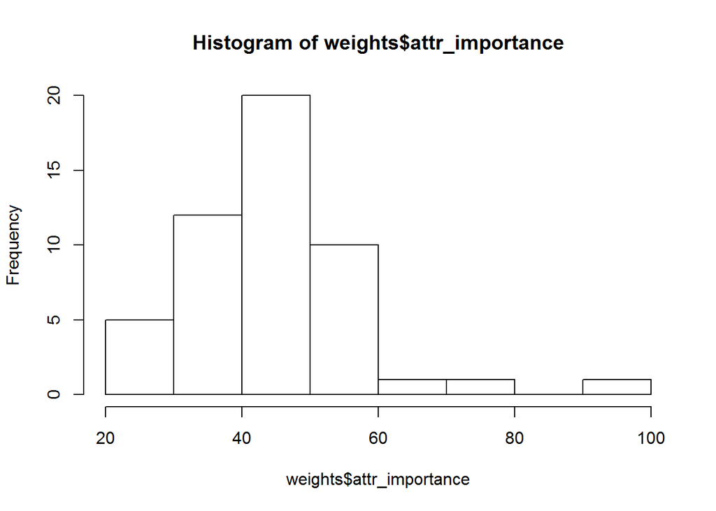

```r
# calculate feature importance weights
weights <- random.forest.importance(classe~., training, importance.type = 1)
hist(weights$attr_importance)
```

Two of the main impact features can be graphed, split by each `class` of exercise. This reveals some differences but no large separations. Clearly, more complex relationships must exist.

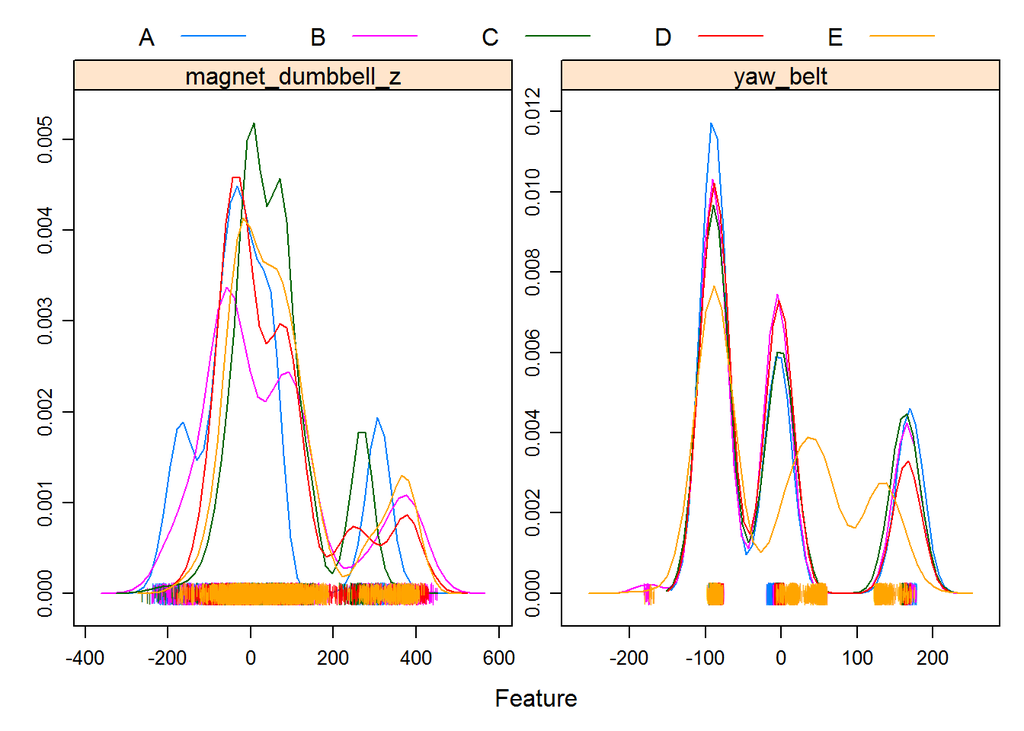

```r
# feature plot of two of the main factors
featurePlot(training[c("yaw_belt","magnet_dumbbell_z")],training$classe,
            "density",
            scales = list(x = list(relation="free"),
                          y = list(relation="free")),
            adjust = 1.5,
            pch = "|",
            auto.key = list(columns = 5))
```

The final formula that will be used for training is then as folllows:

```r
# select top 15 factors bassed on rf importance
subset <- cutoff.k(weights, 15)

# formula for training
formula <- as.simple.formula(subset, "classe")
as.character(formula)
```

```
[1] "classe ~ yaw_belt + magnet_dumbbell_z + magnet_dumbbell_y + pitch_forearm + roll_arm + magnet_forearm_z + gyros_arm_y + gyros_dumbbell_z + accel_dumbbell_z + accel_dumbbell_y + gyros_forearm_z + gyros_belt_z + magnet_belt_x + accel_belt_z + magnet_belt_y"
```

With the primary features identified, we can now train our model. Since this is an attribute response with 5 levels, we will be using a [Random Forrest](https://en.wikipedia.org/wiki/Random_forest) tree ensemble to build a classification model using the selected features from above. To prevent over fitting, we will use a 10 fold Cross Validation strategy to chose the best classification model.

```r
set.seed(825)
# set up cross validation using training control - 10-fold CV
fitControl <- trainControl(method = "cv",number = 10)

# train the modle using formula from above
rfFit <- train(x = training[subset],
               y = training$classe,
               method = "rf",
               prox = TRUE,
               trControl = fitControl,
               verbose = FALSE)

rfFit
```

```
Random Forest

13453 samples
   15 predictor
    5 classes: 'A', 'B', 'C', 'D', 'E'

No pre-processing
Resampling: Cross-Validated (10 fold)

Summary of sample sizes: 12108, 12108, 12107, 12108, 12107, 12107, ...

Resampling results across tuning parameters:

  mtry  Accuracy   Kappa      Accuracy SD  Kappa SD
   2    0.9858030  0.9820366  0.003217305  0.004070992
   8    0.9839444  0.9796914  0.002891076  0.003652533
  15    0.9798570  0.9745205  0.004248023  0.005369404

Accuracy was used to select the optimal model using  the largest value.
The final value used for the model was mtry = 2.
```

## Model Validation and Sample Error

To evaluate the quality of this model, we will predict the response [exercise type] on the `testing` 30% hold-out set from above that was not used in the training. A confusion matrix is used to look at the accuracy of the model’s predictions.

```r
pred <- predict(rfFit,testing); testing$predRight <- pred==testing$classe
# look at table of actual v.s. predicted

confMat <- confusionMatrix(pred,testing$classe)
confMat
```

```
Confusion Matrix and Statistics

          Reference
Prediction    A    B    C    D    E
         A 1638   10    0    1    0
         B    1 1093    9    0    0
         C    1   11  992   17    6
         D    1    1    4  922    1
         E    0    0    0    4 1051

Overall Statistics

               Accuracy : 0.9884
                 95% CI : (0.9853, 0.991)
    No Information Rate : 0.2847
    P-Value [Acc > NIR] : < 2.2e-16

                  Kappa : 0.9853
 Mcnemar's Test P-Value : NA

Statistics by Class:

                     Class: A Class: B Class: C Class: D Class: E
Sensitivity            0.9982   0.9803   0.9871   0.9767   0.9934
Specificity            0.9973   0.9978   0.9926   0.9985   0.9991
Pos Pred Value         0.9933   0.9909   0.9659   0.9925   0.9962
Neg Pred Value         0.9993   0.9953   0.9973   0.9954   0.9985
Prevalence             0.2847   0.1935   0.1744   0.1638   0.1836
Detection Rate         0.2842   0.1897   0.1721   0.1600   0.1824
Detection Prevalence   0.2861   0.1914   0.1782   0.1612   0.1831
Balanced Accuracy      0.9978   0.9891   0.9899   0.9876   0.9963
```

[figure not shown]

## Conclusion

The overall accuracy of the prediction on this hold-out set was 98.8% and the inter-rater agreement for the categorical items statistic [Kappa] is 98.5%. This is very good accuracy given that I only used 15 features and did not take any of the time series data into account. Further more, predictions for the 20 test cases that are needed for submittal resulted in a 20 out of 20 correct score.

#### References

Velloso, E.; Bulling, A.; Gellersen, H.; Ugulino, W.; Fuks, H. **Qualitative Activity Recognition of Weight Lifting Exercises.** *Proceedings of 4th International Conference in Cooperation with SIGCHI (Augmented Human ’13)* . Stuttgart, Germany: ACM SIGCHI, 2013.

Read more: http://groupware.les.inf.puc-rio.br/har#ixzz3sKVwnGFq